# Practical Machine Learning Project

Sudhir Kamat

September 15, 2016

## Practical Machine Learning: Final Project

This is the submission towards the final class project for the Practical Machine Learning Course at Coursera.

### Overview:

Using wearable technology devices (such as Fitbit, Jawbone Up, Nike FuelBand, MapMyFitness, etc.) we can collect data about a person’s activities. Such data was experimentally collected from 6 participants who used accelerometers on the belt, forearm, arm, and dumbell. More information is available from the website here: http://groupware.les.inf.puc-rio.br/har

### Data Sources

The training data for this project are available here:

https://d396qusza40orc.cloudfront.net/predmachlearn/pml-training.csv

The test data are available here:

https://d396qusza40orc.cloudfront.net/predmachlearn/pml-testing.csv

### Project Goal

The goal of this project is to predict the manner in which the persons in test-group performed the exercise, in the form of the Target Variable “classe”. The following paragraphs describe data preparation, building of prediction model, its validation, assessment of expected error as well as the 20 predictions using the model built.

### Data Preparation

#### Data Download

```r
df1 <-  read.csv("pml-training.csv", sep = ",", na.strings = c("", "NA", "#DIV/0!"))
dim(df1)
```

```
## [1] 19622   160
```

```r
df2 <-  read.csv("pml-testing.csv", sep = ",", na.strings = c("", "NA", "#DIV/0!"))
dim(df2)
```

```
## [1]  20 160
```

#### Data Partition & Cleaning

The Training data is partitioned into training (60% rows) and test (40% rows) datasets, so that the prediction-model can be built using the training data, and it can be tested for accuracy using the test dataset.

During cleaning we remove the columns that contain too little variation within them, as these do not help us in prediction. We also handle the columns that have high covariance with each other, retaining only those that improve the prediction efficiency. Finally, we remove the columns that have too many missing values (over 70%).

```r
partTrain <- createDataPartition(df1$classe, p=0.6, list=FALSE)
dtTrain <- df1[partTrain, ]
dtTest <- df1[-partTrain, ]
dim(dtTrain)
```

```
## [1] 11776   160
```

```r
dim(dtTest)
```

```
## [1] 7846  160
```

```r
rm(df1)

## Clean the dataset
dtTrain <- dtTrain[, colSums(is.na(dtTrain)) != nrow(dtTrain)]
## remove nearZeroVariation columns
nzv <- nearZeroVar(dtTrain, saveMetrics=TRUE)
dtTrain <- dtTrain[,nzv$nzv==FALSE]

## Remove the first column from the dataset
dtTrain <- dtTrain[c(-1)]

## Remove features having high correlation
  outCol <- which(names(dtTrain) == "classe")
  dtTrainNums <- sapply(dtTrain, is.numeric)
  hiCorrelationCols <- findCorrelation(abs(cor(dtTrain[ , dtTrainNums][,-outCol], use="pairwise.complete.obs")),0.90, verbose=FALSE)
  highCorrFeatures = names(dtTrain)[hiCorrelationCols]
## highCorrFeatures
  dtTrain <- dtTrain[, -hiCorrelationCols]
## str(dtTrain)  ## 11776 obs. of  96 variables remain

## Remove columns having too many NAs.
dtTrain <- dtTrain[, colSums(is.na(dtTrain)) != nrow(dtTrain)]
tmpDf <- dtTrain
for(i in 1:length(dtTrain)) {
  if( sum( is.na( dtTrain[, i] ) ) /nrow(dtTrain) >= .7) {
    for(j in 1:length(tmpDf)) {
      if( length( grep(names(dtTrain[i]), names(tmpDf)[j]) ) == 1)  {
        tmpDf <- tmpDf[ , -j]
      }
    }
  }
}
dtTrain <- tmpDf
rm(tmpDf)
## str(dtTrain)  ## 11776 obs. of  51 variables remain
```

### Prediction Model

Having cleaned the data, we now build separate prediction models and test them on our test dataset.

#### Building Random Forest Model

At first we use the most versatile machine learning method of Random Forest. We also plot the importance of various Variables in our data in prediction.

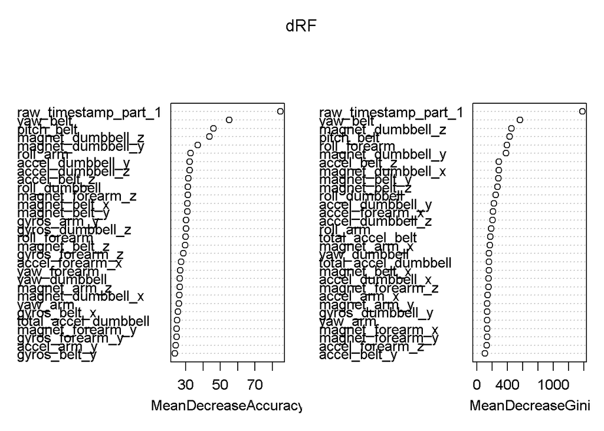

```r
outCol <- which(names(dtTrain) == "classe")
dRF = randomForest(dtTrain[,-outCol], dtTrain[,outCol], importance = T)
## Plotting the importance of variables:
varImpPlot(dRF)
```

Using the variables selected as important, we plot a scatter plot.

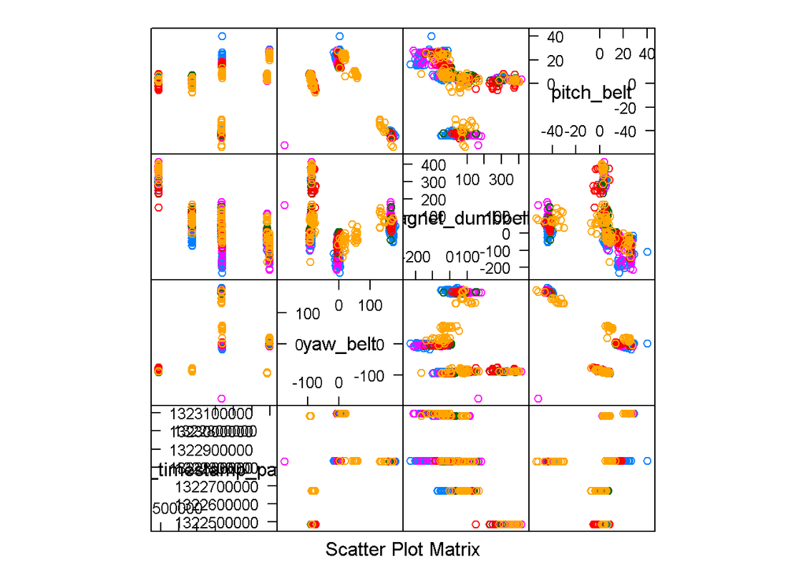

```r
rfImp = data.frame(dRF$importance)
impFeatures = order(-rfImp$MeanDecreaseGini)
inImp = createDataPartition(dtTrain$classe, p = 0.05, list = F)
## Plot the features in a Scatter-plot
featurePlot(dtTrain[inImp,impFeatures[1:4]],dtTrain$classe[inImp], plot = "pairs")
```

#### Building Fitted Decision Tree Model

Subsequently, we use the fitted model object of class “rpart” of R to prepare a decision tree with our training data, and plot the tree to view the result.

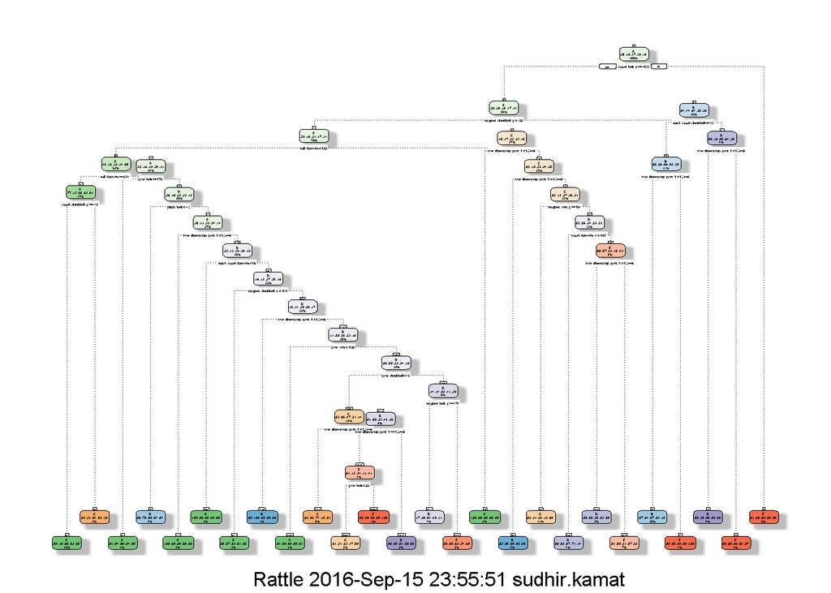

```r
modFitA1 <- rpart(classe ~ ., data=dtTrain, method="class")
## Plot the tree to view it.
fancyRpartPlot(modFitA1)
```

### Testing the Model

```r
dtTest <- dtTest[,colnames(dtTrain)]
dim(dtTest)
```

```
## [1] 7846   51
```

```r
dim(dtTrain)
```

```
## [1] 11776    51
```

#### Testing the Random Forest Model

```r
PredictionRFM <- predict(dRF, dtTest, type = "class")
confusionMatrix(PredictionRFM, dtTest$classe)
```

```
## Confusion Matrix and Statistics
##
##           Reference
## Prediction    A    B    C    D    E
##          A 2228    2    0    0    0
##          B    4 1516    5    0    0
##          C    0    0 1357    5    0
##          D    0    0    6 1281    0
##          E    0    0    0    0 1442
##
## Overall Statistics
##
##                Accuracy : 0.9972
##                  95% CI : (0.9958, 0.9982)
##     No Information Rate : 0.2845
##     P-Value [Acc > NIR] : < 2.2e-16
##
##                   Kappa : 0.9965
##  Mcnemar's Test P-Value : NA
##
## Statistics by Class:
##
##                      Class: A Class: B Class: C Class: D Class: E
## Sensitivity            0.9982   0.9987   0.9920   0.9961   1.0000
## Specificity            0.9996   0.9986   0.9992   0.9991   1.0000
## Pos Pred Value         0.9991   0.9941   0.9963   0.9953   1.0000
## Neg Pred Value         0.9993   0.9997   0.9983   0.9992   1.0000
## Prevalence             0.2845   0.1935   0.1744   0.1639   0.1838
## Detection Rate         0.2840   0.1932   0.1730   0.1633   0.1838
## Detection Prevalence   0.2842   0.1944   0.1736   0.1640   0.1838
## Balanced Accuracy      0.9989   0.9986   0.9956   0.9976   1.0000
```

#### Testing the Fitted Decision Tree Model

```r
predictionFitA1 <- predict(modFitA1, dtTest, type = "class")
confusionMatrix(predictionFitA1, dtTest$classe)
```

```
## Confusion Matrix and Statistics
##
##           Reference
## Prediction    A    B    C    D    E
##          A 2013  145    6   53    2
##          B   69  914   73   33  143
##          C   45  259 1009  252  115
##          D   78  133  104  863   83
##          E   27   67  176   85 1099
##
## Overall Statistics
##
##                Accuracy : 0.7517
##                  95% CI : (0.742, 0.7612)
##     No Information Rate : 0.2845
##     P-Value [Acc > NIR] : < 2.2e-16
##
##                   Kappa : 0.6863
##  Mcnemar's Test P-Value : < 2.2e-16
##
## Statistics by Class:
##
##                      Class: A Class: B Class: C Class: D Class: E
## Sensitivity            0.9019   0.6021   0.7376   0.6711   0.7621
## Specificity            0.9633   0.9497   0.8964   0.9393   0.9446
## Pos Pred Value         0.9072   0.7419   0.6006   0.6844   0.7558
## Neg Pred Value         0.9611   0.9087   0.9418   0.9358   0.9463
## Prevalence             0.2845   0.1935   0.1744   0.1639   0.1838
## Detection Rate         0.2566   0.1165   0.1286   0.1100   0.1401
## Detection Prevalence   0.2828   0.1570   0.2141   0.1607   0.1853
## Balanced Accuracy      0.9326   0.7759   0.8170   0.8052   0.8534
```

### Model Selection & Prediction

We notice that the model built using Random Forest is giving us better accuracy than the one with Fitted Decision Tree. Therefore, we use that model to predict the target variables using the test dataset.

```r
## Trim the test dataset by removing unwanted columns
dNames <- colnames(dtTest)
length(dNames) <-  length(dNames)-1
df2 <- df2[,dNames]
dim(df2)
```

```
## [1] 20 50
```

```r
## Coerce the column data types to match that of the training data types
for (i in 1:length(df2) ) {
  for(j in 1:length(dtTest)) {
    if( length( grep(names(dtTest[i]), names(df2)[j]) ) ==1)  {
      class(df2[j]) <- class(dtTest[i])
    }
  }
}

## Confirm the data types are matching by adding a row and deleting it.
 df2 <- rbind(dtTest[2, -ncol(dtTest)] , df2)
 df2 <- df2[-1,]

## Use the Predict function with Random Forest Model
 predictionFinal <- predict(dRF, df2)
 predictionFinal
```

```
## 22  3  4  5  6  7  8  9 10 11 12 13 14 15 16 17 18 19 20 21
##  B  A  B  A  A  E  D  B  A  A  B  C  B  A  E  E  A  B  B  B
## Levels: A B C D E
```